# Coursework Report

*N* removed NAs: 3

*N* removed typo: 1

*N* removed <18: 29

*N* total clean: 117

| Group | *N* | *M*<sub>age</sub> | *M*<sub>rating</sub> |
| --- | --- | --- | --- |
| Control | 62 | 20.5 | 5.84 |
| Experim | 55 | 20.6 | 6.62 |

**Main analysis results**

*t*(115) = -5.62, *p* < .001

[interactive chart not shown]

[figure not shown]

[interactive chart not shown]

# Coursework Report

Analysing Data, Spring 2020

# Methods

## Participants

Table 1: Descriptive statistics by experimental group

| Group | N | Mean Age | SD Age |
| --- | --- | --- | --- |
| white | 62 | 20.5 | 1.97 |
| red | 55 | 20.6 | 1.84 |

## Design

This experiment was designed to replicate one of the studies previously examined in the paper “Red, Rank, and Romance in Women Viewing Men” by A. J. Elliot et al (2010). The hypothesis under investigation was that red enhances women’s attraction to men. In the original study it was suggested that this would occur due to the colour red increasing the woman’s perception of the man’s status, which in turn would amplify her attraction to him.

To evaluate this hypothesis, we conducted a replication study with a between-subject design. Before our study commenced, we ensured that we obtained informed consent from all of our participants and made them aware that they could leave the experiment at any time or request to have their data withdrawn up to a month after the study had ended. In the experiment, our female participants were asked to view a black and white photograph of a man for 5 seconds. This photograph was either surrounded by a white or red border, which was our independent variable. Each participant was then asked three questions in order to gauge how attractive they perceived the man in the photograph to be (serving as our dependent variable). The first question related to how attractive the person was, the second to how pleasant the person was to look at, and the third to how attractive the participants would find him if they were to meet him in person. All three of these variables were assessed as a rating between one to nine, where one described the photographed man as “not at all attractive”, and nine being “extremely attractive”. The three ratings given in relation to the three variables were then averaged out to create a composite score for each participant, producing the quantitative data necessary to assess our results.

Our hypothesis was to investigate whether changing the border of a photographed man to the colour red would alter how attractive women rated this man on a 9-point scale. We will be using a t-test in order to analyse the results we obtained from our study as this statistical test will allow us to compare the data between both experimental groups efficiently.

# Results

The graph below represents the relationship our data found between the experimental condition and the mean attractiveness rating given by our participants. Overall, it suggests that when the frame of the photograph was red, the mean attractiveness rating was higher in relation to the mean attractiveness rating given for the control condition. In addition, Table 2 illustrates the mean rating and standard deviation of the ratings for each item assessed by the participants for each experimental condition. It suggests that, on average, the mean ratings for the items from the red experimental group were greater than those in the white control group.

In order to further investigate these findings and expand on this conclusion, we decided to conduct a statistical two-tailed t-test. The results from the *t*-test indicated that colour did in fact have an effect on how attractive our participants perceived the photographed man to be. In particular, the colour red was observed to enhance attraction in comparison to the white control. Our results indicated that our participants’ mean attraction ratings were higher in the red condition (*M* = 6.62) as opposed to their ratings for the white condition (*M* = 5.84). The difference between these means were significant (*M*<sub>diff</sub> = -0.78, 95% CI [-1.05, -0.5], *t* (115) = -5.62, *p* <.001), suggesting that female participants felt more attracted to the man used in our study when the photograph was surrounded by a red border, which supports our hypothesis.

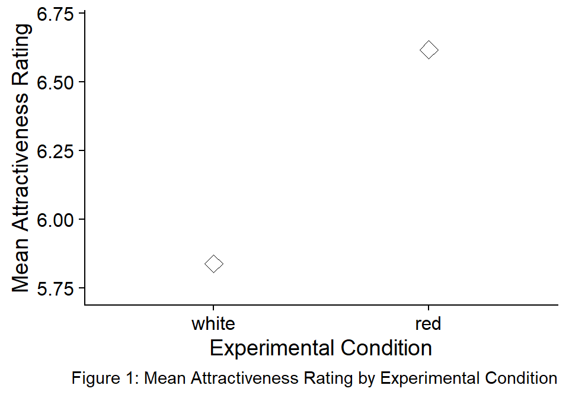

Table 2: Mean and standard deviations of ratings by experimental group

| Group | Item 1 Mean | Item 1 SD | Item 2 Mean | Item 2 SD | Item 3 Mean | Item 3 SD |
| --- | --- | --- | --- | --- | --- | --- |
| white | 5.73 | 1.3 | 5.81 | 1.3 | 5.98 | 1.29 |
| red | 6.47 | 1.4 | 6.56 | 1.3 | 6.82 | 1.33 |

# Discussion

Overall, our results have suggested that the colour red can influence male attractiveness from the perception of women. Although the strength of this association may be influenced by other factors, we can at least conclude that there is some connection between these two variables.

In the original study conducted by Elliot et al (2010), they obtained similar results which also indicated that participants in the red condition rated the man as more attractive in relation to participants in the white condition. By conducting a replication of this study with a larger sample size than the original study used, we can be more certain that the results obtained in both our study and the original study are significant.

However, when investigating the results obtained from other replications of Elliot et al’s study, this reliability becomes questionable. A large majority of replication studies’ results have conflicted with those of the original study. Studies executed by Wagge et al (2019), Haran and Briggs (2016), and Lehmann and Calin-Jageman (2017) loyally replicated the original study in hopes of discovering the same effect as Elliot et al did, however their results showed contradicting findings. In all three studies the results indicated that there were no significant differences in attraction between the two conditions. As the results from these replication studies suggest no relationship between the colour red and attraction, it casts doubt across the results obtained in the original experiment and may indicate that further research is needed in this field of study. However, in all three replications the experimenters focussed on replicating experiment 3, whereas we replicated experiment 1. This means that where we used the two conditions of a red or white border, they used the conditions of a red or grey background, which may have accounted for the difference in findings. Nonetheless, their results still indicate a lack of evidence for the hypothesis that the original study was designed to investigate. The amount of opposing findings from studies such as those above makes us question whether the effect that red has on attraction is a valid conclusion and whether it can be observed outside of the laboratory setting.

During the analysis of our data, we observed both strengths and weaknesses within our study which may have affected the validity and reliability of our results. Some strengths of our study included our sample size as it was considerably larger than that used in the original study, allowing us to gain a more accurate accumulation of results. Also, the use of a between-subjects design made it less likely that the participants would guess the aim of our experiment, as each participant was only exposed to one condition of the experiment. Likewise, our experiment was conducted in a controlled environment allowing us to have high internal validity, as the amount of distractions in the surrounding area were minimised. We were also able to control all other aspects of the photograph other than our independent variable (such as the male used in the photograph, how long the participants were able to view it, etc), which allowed us to conclude any differences seen between the two groups was down to the variable we had manipulated.

Albeit there were a lot of strengths of our research, there were also some limitations to it. For example, although the use of a between-subjects design was beneficial in some respects, it also meant that individual differences between the two groups were not identical. This means that the difference observed between the two groups may have been due to other factors rather than the variable we aimed to investigate. In addition to this, the task itself yielded quite low mundane realism as it didn’t represent a real-life experience that occurs in everyday life or is even part of the process of choosing a romantic partner. Furthermore, the use of photographs gives our experiment low external validity as it does not generalise well to real-life situations. Lastly, the use of our 9-point scale can be judged as subjective as there is no operationalisation of the terms “extremely attractive” or “not attractive”, and these will mean different things to different people.

This area of study has received an increasing amount of attention, however, there continues to be some aspects of this research which are yet to be expanded upon. Firstly, a study run by Feinman and Gill (1978) discovered that women have a tendency to like men with dark eyes, dark hair, and dark complexion. Also, research conducted by Wiederman and Allgeier (1992) found that women place more value on features such as good financial prospect than they do on physical appearance. It would be intriguing to investigate whether these physical and socioeconomical features would be overridden by the effect that red is seen to have on female attraction to males. This phenomenon has briefly been analysed by Young (2015) as he found that red only enhances attractiveness when the person is previously considered to be highly attractive. This could demonstrate that other facial features which are seen as unattractive diminish the effect that red has on attraction.

Alternatively, replications that have been based upon Elliot et al’s original research have focussed on either men’s attraction to women or women’s attraction to men, however only a very limited amount of research has explored whether these findings are consistent for same-sex relationships. Although this phenomenon was studied in Elliot et al’s second experiment, results from other studies investigating the same concept found contradicting results (Roberts, Owen & Havlicek, 2010). Due to these conflicting conclusions, more research should be conducted in order to produce a conclusive verdict on whether red influences attraction in same-sex relationships.

Lastly, in Elliot et al’s paper there is a suggestion that red may be seen to enhance the attraction of males as it is associated with high status, and this in turn can attract women as it symbolises the potential for a more successful mating partner. As Elliot et al conducted their research on undergraduates, this connotation of red may not have had the same effect as it would have on a more mature sample. Thus, future studies may be able to observe whether attraction is intensified at a greater rate due to this association if the sample consists of a more mature age-range, where the prospect of finding a reproductive partner is more evident.

In conclusion, our findings did suggest a relationship between red and attraction, thus confirming Elliot et al’s original findings that red can increase male attractiveness. However, due to the conflicting evidence produced by many other replication studies, I question whether this effect is one with the reliability and validity to be regarded as a trusted association. I believe that in order to determine whether this concept is credible or not, further research must be carried out to investigate it in more depth.

# References

Elliot, A. J., Kayser, D. N., Greitemeyer, T., Lichtenfeld, S., Gramzow, R. H., Maier, M. A., & Liu, H. (2010). Red, rank, and romance in women viewing men. *Journal of Experimental Psychology: General*, *139*(3), 399–417. doi: 10.1037/a0019689

Feinman, S., & Gill, G. W. (1978). Sex Differences in Physical Attractiveness Preferences. *The Journal of Social Psychology*, *105*(1), 43–52. doi: 10.1080/00224545.1978.9924089

Haran, K., & Briggs, S. G. (2016). Red, Rank, and Romance in Women Viewing Men: A Replication Study. *UC Merced Undergraduate Research Journal*, *8*(2). Retrieved from https://escholarship.org/uc/item/5b60s9dw

Lehmann, G. K., & Calin-Jageman, R. J. (2017). Is Red Really Romantic? *Social Psychology*, *48*(3), 174–183. doi: 10.1027/1864-9335/a000296

Roberts, S. C., Owen, R. C., & Havlicek, J. (2010). Distinguishing between Perceiver and Wearer Effects in Clothing Color-Associated Attributions. *Evolutionary Psychology*, *8*(3), 147470491000800.

Wagge, J. R., Baciu, C., Banas, K., Nadler, J. T., Schwarz, S., Weisberg, Y., … Grahe, J. (2019). A Demonstration of the Collaborative Replication and Education Project: Replication Attempts of the Red-Romance Effect. *Collabra: Psychology*, *5*(1), 5. doi: 10.1525/collabra.177

Wiederman, M. W., & Allgeier, E. R. (1992). Gender differences in mate selection criteria: Sociobiological or socioeconomic explanation? *Ethology and Sociobiology*, *13*(2), 115–124. doi: 10.1016/0162-3095(92)90021-u

Young, S. G. (2015). The effect of red on male perceptions of female attractiveness: Moderation by baseline attractiveness of female faces. *European Journal of Social Psychology*, *45*(2), 146–151. doi: 10.1002/ejsp.2098